# Lab 1

1. Install R and Rstudio.
2. Open Rstudio and install the two packages `rmarkdown` and `tinytex`.
3. Download this rmd file by clicking on ‘Code > Download Rmd’ on the top right bottom of this html page.
4. Enter you Name, Surname and Student Number after ‘author:’ in the Header of the rmd file.

This is a code chunk:

```r
a <- 1:10 # sequence of numbers from 1 to 10 saved in the object called 'a'
a
```

```
##  [1]  1  2  3  4  5  6  7  8  9 10
```

5. Press the green triangle button on the toolbar (top right) of a code chunk that has the tooltip ‘Run Current Chunk’ to execute the code and produce the output.

When code is executed, its output appears beneath the code chunk that produced it.

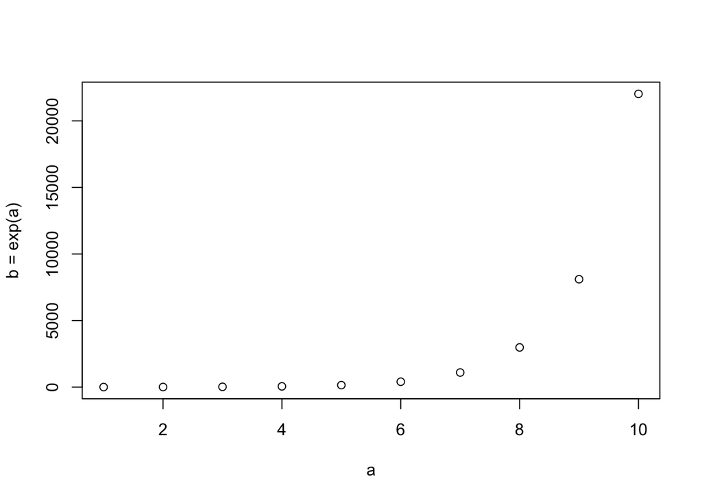

```r
b <- exp(a)
plot(b, xlab = 'a', ylab = 'b = exp(a)')
```

6. Execute all the chunks and preview the notebook by clicking the ‘Preview’ button in the editor toolbar.

**NB** The notebook preview does **not** execute any of your R code chunks. It simply shows you a rendered copy of the output of your document along with the most recent chunk output.

This will generate a file called ‘lab_1.nb.html’.